# Squeezing R with awesome packages

Adrian Lopez Garcia

11/12/2019

# PART I: TIDYVERSE

[figure not shown]

Lets install tidyverse:

```r
install.packages("tidyverse")
```

For more info, you can check the [tidyverse site](https://www.tidyverse.org/), or the book “R for Data Science” (available online [here](https://r4ds.had.co.nz/)).

# TIBBLE

[figure not shown]

> [OVERVIEW](https://tibble.tidyverse.org/)

Lets load some data…

```r
fpkm <- read.table("data/curso_R_fpkm.tsv", header = TRUE, sep='\t', dec=',')
phenot <- read.table("data/curso_R_fenot.csv", header = TRUE, sep=',', dec='.')
microb <- read.table("data/curso_R_microb.csv", header = TRUE, stringsAsFactors = FALSE, sep=';', dec='.')
```

```
as_tibble(fpkm)
as_tibble(phenot)
as_tibble(microb)
```

```
## # A tibble: 65 x 13
##    Gene.ID.Shortna~    Sam1    Sam2   Sam3    Sam4    Sam5    Sam6    Sam7    Sam8    Sam9   Sam10
##    <fct>              <dbl>   <dbl>  <dbl>   <dbl>   <dbl>   <dbl>   <dbl>   <dbl>   <dbl>   <dbl>
##  1 XLOC_000013;DAC~  7.24   7.09e+0  7.49   6.03    9.13    7.99    8.20   8.95e+0 7.27e+0   9.51
##  2 XLOC_000014;FRM~ 53.3    1.05e+2 75.7   55.8    83.5    64.5    57.4    6.60e+1 1.38e+2 127.
##  3 XLOC_000015;UNC~  0.726  5.51e-1  1.03   0.569   0.399   0.445   1.10   7.97e-1 5.38e-1   0.740
##  4 XLOC_000016;TTL~  8.61   6.53e+0  8.13   8.02    5.79    5.55    8.31   7.38e+0 6.72e+0   6.97
##  5 XLOC_000017;GPR~  0.307  2.78e-1  0.137  0.154   0.0218  0.0781  0.335  4.06e-7 2.65e-1   0.218
##  6 XLOC_000018;C8o~  0      1.38e-1  0      0       0.0293  0       0      0.      9.90e-2   0
##  7 XLOC_002969;GRE~  0.0434 6.39e-2  0      0.0207  0.0226  0       0.0173 0.      2.98e-2   0
##  8 XLOC_002970;RGS~  2.90   6.85e-1  1.95   2.01    0.476   0.784   0.642  6.06e-1 9.05e-1   1.42
##  9 XLOC_002971;FH;~  0      1.49e-1  0      0.0853  0       0.0830  0      0.      0.        0.104
## 10 XLOC_002972;ZNF~ 23.7    2.12e+1 22.8   23.2    22.6    21.5    24.0    2.54e+1 2.20e+1  18.8
## # ... with 55 more rows, and 2 more variables: Sam11 <dbl>, Sam12 <dbl>
```

```
## # A tibble: 24 x 8
##    ID_sample Breed  Diet Weight..kg. Weight.month Loin.weight.1 Loin.weight.2   WHC
##    <fct>     <fct> <int>       <dbl>        <int>         <dbl>         <dbl> <dbl>
##  1 Sample 1  IB        1        98.5           10         NA            NA     NA
##  2 Sample 1  IB        1       120.            13          2.19          2.4   21.5
##  3 Sample 2  DU        1        99.9           10         NA            NA     NA
##  4 Sample 2  DU        1       135.            13          2.28          2.24  23.7
##  5 Sample 3  IB        1       100.            10         NA            NA     NA
##  6 Sample 3  IB        1       133.            13          2.29          2.36  20.6
##  7 Sample 4  IB        1        98.8           10         NA            NA     NA
##  8 Sample 4  IB        1       129.            13          2.26          2.4   24.6
##  9 Sample 5  DU        1       101.            10         NA            NA     NA
## 10 Sample 5  DU        1       137.            13          1.95          1.89  24.2
## # ... with 14 more rows
```

```
## # A tibble: 7 x 12
##   Kingdom  Phylum   Class    Order      Family     Genus          Sam1  Sam2  Sam3  Sam4  Sam5  Sam6
##   <chr>    <chr>    <chr>    <chr>      <chr>      <chr>         <dbl> <dbl> <dbl> <dbl> <dbl> <dbl>
## 1 Bacteria Bactero~ Bactero~ Bacteroid~ Rikenella~ Rikenellacea~  5242  1597     0  2312     0  1994
## 2 Bacteria Firmicu~ Clostri~ Clostridi~ Ruminococ~ Ruminococcac~   101     0     0  2644     0  2415
## 3 Bacteria Bactero~ Bactero~ Bacteroid~ Prevotell~ Prevotella 2   2010   500   375  2602  4702  1343
## 4 Bacteria Bactero~ Bactero~ Bacteroid~ Tannerell~ Parabacteroi~     0   505   648     0   952   482
## 5 Bacteria Bactero~ Bactero~ Bacteroid~ Prevotell~ Prevotella 2      0     0     0  2383  4046  1122
## 6 Archaea  Euryarc~ Thermop~ Methanoma~ Methanome~ Methanomethy~    25     0    78     0     0    11
## 7 Archaea  Euryarc~ Methano~ Methanoba~ Methanoba~ Methanobrevi~    15     1     7     0     2    19
```

# DPLYR

[figure not shown]

> [CHEATSHEET](https://github.com/rstudio/cheatsheets/blob/master/data-transformation.pdf)

## Data transformation

```r
head(phenot)
```

```
##   ID_sample Breed Diet Weight..kg. Weight.month Loin.weight.1 Loin.weight.2    WHC
## 1  Sample 1    IB    1        98.5           10            NA            NA     NA
## 2  Sample 1    IB    1       120.1           13          2.19          2.40 21.504
## 3  Sample 2    DU    1        99.9           10            NA            NA     NA
## 4  Sample 2    DU    1       135.4           13          2.28          2.24 23.734
## 5  Sample 3    IB    1       100.4           10            NA            NA     NA
## 6  Sample 3    IB    1       133.2           13          2.29          2.36 20.632
```

[output not shown]

### A short parenthesis!! - **PIPING**

The dplyr pipe `%>%` is an operator inherited from `magrittr` which takes the output from one function and uses it as input for the next one (just like Unix `|` pipe).

```r
mean(phenot$WHC, na.rm = T)
```

```
## [1] 23.70342
```

```r
phenot$WHC %>% mean(na.rm = T)
```

```
## [1] 23.70342
```

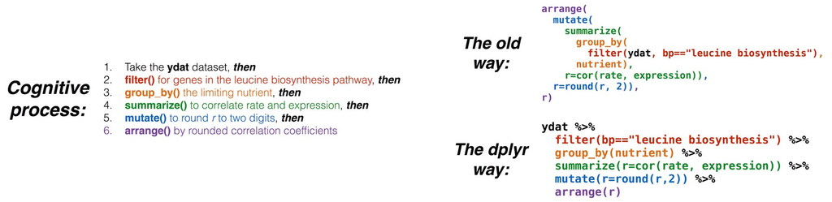

### 1) Rename columns

We use `dplyr::rename()` function to change specified column names.

```r
phenot %>%
  rename(Weight_kg = Weight..kg., Month = Weight.month, LoinW_1 = Loin.weight.1, LoinW_2 = Loin.weight.2) %>%
  head
```

```
##   ID_sample Breed Diet Weight_kg Month LoinW_1 LoinW_2    WHC
## 1  Sample 1    IB    1      98.5    10      NA      NA     NA
## 2  Sample 1    IB    1     120.1    13    2.19    2.40 21.504
## 3  Sample 2    DU    1      99.9    10      NA      NA     NA
## 4  Sample 2    DU    1     135.4    13    2.28    2.24 23.734
## 5  Sample 3    IB    1     100.4    10      NA      NA     NA
## 6  Sample 3    IB    1     133.2    13    2.29    2.36 20.632
```

But this is MADNESS when we must rename **100 columns**… What should we do??

1. **If every column name to change follows a pattern:**  
   I.e., columns with “.weight.” in their name.

```r
phenot %>% rename_at(vars(contains(".weight.")), funs(str_replace(., ".weight.", "W_"))) %>% head
```

```
##   ID_sample Breed Diet Weight..kg. Weight.month LoinW_1 LoinW_2    WHC
## 1  Sample 1    IB    1        98.5           10      NA      NA     NA
## 2  Sample 1    IB    1       120.1           13    2.19    2.40 21.504
## 3  Sample 2    DU    1        99.9           10      NA      NA     NA
## 4  Sample 2    DU    1       135.4           13    2.28    2.24 23.734
## 5  Sample 3    IB    1       100.4           10      NA      NA     NA
## 6  Sample 3    IB    1       133.2           13    2.29    2.36 20.632
```

2. **If no pattern is detected:**

```r
oldnames <- c("Weight..kg.", "Weight.month", "Loin.weight.1", "Loin.weight.2")
newnames <- c("Weight_kg", "Month", "LoinW_1", "LoinW_2")

# Classic way:
phenot2 <- phenot
old.cols <- which(colnames(phenot2) %in% oldnames) # Same as: old.cols <- 4:7
colnames(phenot2)[old.cols] <- c("Weight_kg", "Month", "LoinW_1", "LoinW_2")

# dplyr way:
phenot2 <- phenot %>% rename_at(vars(oldnames), ~ newnames)

head(phenot2)
```

```
##   ID_sample Breed Diet Weight_kg Month LoinW_1 LoinW_2    WHC
## 1  Sample 1    IB    1      98.5    10      NA      NA     NA
## 2  Sample 1    IB    1     120.1    13    2.19    2.40 21.504
## 3  Sample 2    DU    1      99.9    10      NA      NA     NA
## 4  Sample 2    DU    1     135.4    13    2.28    2.24 23.734
## 5  Sample 3    IB    1     100.4    10      NA      NA     NA
## 6  Sample 3    IB    1     133.2    13    2.29    2.36 20.632
```

> **SOME TRAINING**  
> Use `dplyr::rename()` or another method to change the column names, and save it inside `phenot` variable.

```r
phenot <- phenot %>%
  rename(Weight_kg = Weight..kg., Month = Weight.month, LoinW_1 = Loin.weight.1, LoinW_2 = Loin.weight.2)
```

### 2) Collapse many values to a single summary

At certain situations we will need to group our dataset based on one or multiple categorical columns. The `summarise()` function, together with `group_by()`, does the job.

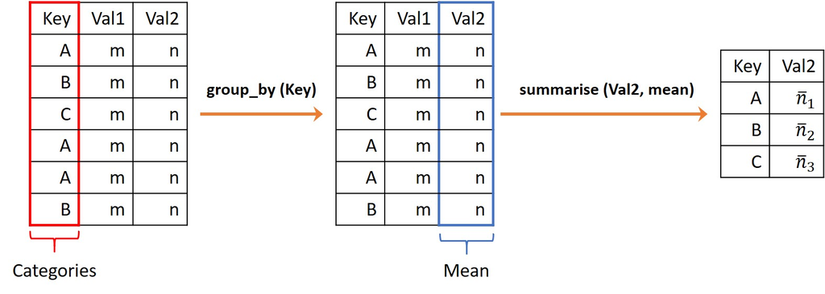

```r
phenot %>%
  group_by(Breed, Diet) %>%
  summarise_at(c("LoinW_1", "LoinW_2", "WHC"), mean, na.rm = T)
```

```
## # A tibble: 4 x 5
## # Groups:   Breed [2]
##   Breed  Diet LoinW_1 LoinW_2   WHC
##   <fct> <int>   <dbl>   <dbl> <dbl>
## 1 DU        1    2.25    2.20  24.4
## 2 DU        2    2.14    2.15  26.1
## 3 IB        1    2.25    2.39  22.2
## 4 IB        2    1.93    1.99  22.1
```

Utilities:

- Get basic statistics for any variable(s) keeping a tabular format.

```r
phenot %>%
  group_by(Breed, Diet) %>%
  summarise_at(c("LoinW_1", "LoinW_2", "WHC"), list(Mean=mean, SD=sd, Max=max, Min=min), na.rm=T)
```

```
## # A tibble: 4 x 14
## # Groups:   Breed [2]
##   Breed  Diet LoinW_1_Mean LoinW_2_Mean WHC_Mean LoinW_1_SD LoinW_2_SD WHC_SD LoinW_1_Max
##   <fct> <int>        <dbl>        <dbl>    <dbl>      <dbl>      <dbl>  <dbl>       <dbl>
## 1 DU        1         2.25         2.20     24.4     0.291      0.287   0.781        2.53
## 2 DU        2         2.14         2.15     26.1     0.149      0.124   4.03         2.31
## 3 IB        1         2.25         2.39     22.2     0.0513     0.0231  2.09         2.29
## 4 IB        2         1.93         1.99     22.1     0.129      0.147   2.66         2.04
## # ... with 5 more variables: LoinW_2_Max <dbl>, WHC_Max <dbl>, LoinW_1_Min <dbl>,
## #   LoinW_2_Min <dbl>, WHC_Min <dbl>
```

- Agglomerate table using specific classification levels.

```r
as_tibble(microb)
```

```
## # A tibble: 7 x 12
##   Kingdom  Phylum   Class    Order      Family     Genus          Sam1  Sam2  Sam3  Sam4  Sam5  Sam6
##   <chr>    <chr>    <chr>    <chr>      <chr>      <chr>         <dbl> <dbl> <dbl> <dbl> <dbl> <dbl>
## 1 Bacteria Bactero~ Bactero~ Bacteroid~ Rikenella~ Rikenellacea~  5242  1597     0  2312     0  1994
## 2 Bacteria Firmicu~ Clostri~ Clostridi~ Ruminococ~ Ruminococcac~   101     0     0  2644     0  2415
## 3 Bacteria Bactero~ Bactero~ Bacteroid~ Prevotell~ Prevotella 2   2010   500   375  2602  4702  1343
## 4 Bacteria Bactero~ Bactero~ Bacteroid~ Tannerell~ Parabacteroi~     0   505   648     0   952   482
## 5 Bacteria Bactero~ Bactero~ Bacteroid~ Prevotell~ Prevotella 2      0     0     0  2383  4046  1122
## 6 Archaea  Euryarc~ Thermop~ Methanoma~ Methanome~ Methanomethy~    25     0    78     0     0    11
## 7 Archaea  Euryarc~ Methano~ Methanoba~ Methanoba~ Methanobrevi~    15     1     7     0     2    19
```

We may want to analyze our OTUs at Class level instead of Genus level…

```r
microb %>%
  group_by(Kingdom, Phylum, Class) %>%
  summarise_if(is.numeric, sum)
```

```
## # A tibble: 4 x 9
## # Groups:   Kingdom, Phylum [3]
##   Kingdom  Phylum        Class            Sam1  Sam2  Sam3  Sam4  Sam5  Sam6
##   <chr>    <chr>         <chr>           <dbl> <dbl> <dbl> <dbl> <dbl> <dbl>
## 1 Archaea  Euryarchaeota Methanobacteria    15     1     7     0     2    19
## 2 Archaea  Euryarchaeota Thermoplasmata     25     0    78     0     0    11
## 3 Bacteria Bacteroidetes Bacteroidia      7252  2602  1023  7297  9700  4941
## 4 Bacteria Firmicutes    Clostridia        101     0     0  2644     0  2415
```

> **SOME TRAINING**  
> Use `dplyr::summarise()` or other method to make a new variable called `ADG` (average daily gain), grouped by sample name, making the difference between weight (kg) at 13th and 10th month, and dividing it by 90 days. Then, save it inside a new `adg` data frame.

```r
adg <- phenot %>%
  group_by(ID_sample) %>%
  summarise(ADG = diff(Weight_kg)/90)

adg <- phenot %>%
  group_by(ID_sample) %>%
  summarise_at(c("Weight_kg"), function(x){diff(x)/90}) %>%
  rename(ADG = Weight_kg)

adg
```

```
## # A tibble: 12 x 2
##    ID_sample   ADG
##    <fct>     <dbl>
##  1 Sample 1  0.240
##  2 Sample 10 0.407
##  3 Sample 11 0.402
##  4 Sample 12 0.337
##  5 Sample 2  0.394
##  6 Sample 3  0.364
##  7 Sample 4  0.34
##  8 Sample 5  0.394
##  9 Sample 6  0.382
## 10 Sample 7  0.363
## 11 Sample 8  0.398
## 12 Sample 9  0.3
```

### 3) Create new variables according to existing ones

Function `mutate()` creates new columns based on the values of other existing columns. Now, we will create a new column which is a modification of WHC (water holding capacity), transforming the precentage units into decimals.

```r
phenot <- phenot %>% mutate(WHC_dec = WHC/100)
as_tibble(phenot)
```

```
## # A tibble: 24 x 9
##    ID_sample Breed  Diet Weight_kg Month LoinW_1 LoinW_2   WHC WHC_dec
##    <fct>     <fct> <int>     <dbl> <int>   <dbl>   <dbl> <dbl>   <dbl>
##  1 Sample 1  IB        1      98.5    10   NA      NA     NA    NA
##  2 Sample 1  IB        1     120.     13    2.19    2.4   21.5   0.215
##  3 Sample 2  DU        1      99.9    10   NA      NA     NA    NA
##  4 Sample 2  DU        1     135.     13    2.28    2.24  23.7   0.237
##  5 Sample 3  IB        1     100.     10   NA      NA     NA    NA
##  6 Sample 3  IB        1     133.     13    2.29    2.36  20.6   0.206
##  7 Sample 4  IB        1      98.8    10   NA      NA     NA    NA
##  8 Sample 4  IB        1     129.     13    2.26    2.4   24.6   0.246
##  9 Sample 5  DU        1     101.     10   NA      NA     NA    NA
## 10 Sample 5  DU        1     137.     13    1.95    1.89  24.2   0.242
## # ... with 14 more rows
```

### 4) Pick variables by their names

Now, we will take only the classification factors, animal weight, loin weights and water holding capacity in decimal terms, using `select()`function. Notice that column order **changes** according to input order.

```r
phenot_sub <- phenot %>% select(ID_sample, Breed, Diet, Weight_kg, LoinW_1, LoinW_2, WHC_dec)
as_tibble(phenot_sub)
```

```
## # A tibble: 24 x 7
##    ID_sample Breed  Diet Weight_kg LoinW_1 LoinW_2 WHC_dec
##    <fct>     <fct> <int>     <dbl>   <dbl>   <dbl>   <dbl>
##  1 Sample 1  IB        1      98.5   NA      NA     NA
##  2 Sample 1  IB        1     120.     2.19    2.4    0.215
##  3 Sample 2  DU        1      99.9   NA      NA     NA
##  4 Sample 2  DU        1     135.     2.28    2.24   0.237
##  5 Sample 3  IB        1     100.    NA      NA     NA
##  6 Sample 3  IB        1     133.     2.29    2.36   0.206
##  7 Sample 4  IB        1      98.8   NA      NA     NA
##  8 Sample 4  IB        1     129.     2.26    2.4    0.246
##  9 Sample 5  DU        1     101.    NA      NA     NA
## 10 Sample 5  DU        1     137.     1.95    1.89   0.242
## # ... with 14 more rows
```

### 5) Select rows by column values

Here we use `dplyr::filter()` function to subset data frame under one specific condition. For example, we would like to remove rows with NA data in our data subset.

```r
phenot_sub <- phenot_sub %>% filter(!is.na(LoinW_1) & !is.na(LoinW_2) & !is.na(WHC_dec))
phenot_sub
```

```
##    ID_sample Breed Diet Weight_kg LoinW_1 LoinW_2 WHC_dec
## 1   Sample 1    IB    1     120.1    2.19    2.40 0.21504
## 2   Sample 2    DU    1     135.4    2.28    2.24 0.23734
## 3   Sample 3    IB    1     133.2    2.29    2.36 0.20632
## 4   Sample 4    IB    1     129.4    2.26    2.40 0.24609
## 5   Sample 5    DU    1     136.6    1.95    1.89 0.24204
## 6   Sample 6    DU    1     133.3    2.53    2.46 0.25259
## 7   Sample 7    IB    2     129.8    1.97    2.15 0.22235
## 8   Sample 8    DU    2     137.8    2.03    2.01 0.21941
## 9   Sample 9    IB    2     122.2    1.79    1.86 0.19396
## 10 Sample 10    DU    2     139.1    2.31    2.23 0.26219
## 11 Sample 11    DU    2     135.7    2.08    2.22 0.30006
## 12 Sample 12    IB    2     130.3    2.04    1.96 0.24702
```

### 6) Join tables

This package includes some generic functions for merging tables, with a more comprehensive syntax and much more processing speed (important when working with huge tables). Check `?dplyr::join` to find out how joining functions work.

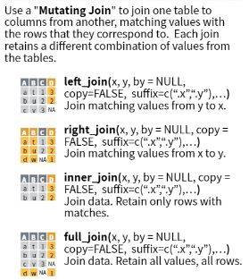

We will now join our `phenot_sub` and `adg` datasets:

```r
phenot_sub <- full_join(phenot_sub, adg, by = "ID_sample")
as_tibble(phenot_sub)
```

```
## # A tibble: 12 x 8
##    ID_sample Breed  Diet Weight_kg LoinW_1 LoinW_2 WHC_dec   ADG
##    <fct>     <fct> <int>     <dbl>   <dbl>   <dbl>   <dbl> <dbl>
##  1 Sample 1  IB        1      120.    2.19    2.4    0.215 0.240
##  2 Sample 2  DU        1      135.    2.28    2.24   0.237 0.394
##  3 Sample 3  IB        1      133.    2.29    2.36   0.206 0.364
##  4 Sample 4  IB        1      129.    2.26    2.4    0.246 0.34
##  5 Sample 5  DU        1      137.    1.95    1.89   0.242 0.394
##  6 Sample 6  DU        1      133.    2.53    2.46   0.253 0.382
##  7 Sample 7  IB        2      130.    1.97    2.15   0.222 0.363
##  8 Sample 8  DU        2      138.    2.03    2.01   0.219 0.398
##  9 Sample 9  IB        2      122.    1.79    1.86   0.194 0.3
## 10 Sample 10 DU        2      139.    2.31    2.23   0.262 0.407
## 11 Sample 11 DU        2      136.    2.08    2.22   0.300 0.402
## 12 Sample 12 IB        2      130.    2.04    1.96   0.247 0.337
```

### 7) Reorder rows

Another `dplyr` application is reordering rows based on the table’s variables. For example, we would like to rearrange our animal samples first by breed and then by their weight.

```r
phenot_sub <- phenot_sub %>% arrange(Breed, Weight_kg)
as_tibble(phenot_sub)
```

```
## # A tibble: 12 x 8
##    ID_sample Breed  Diet Weight_kg LoinW_1 LoinW_2 WHC_dec   ADG
##    <fct>     <fct> <int>     <dbl>   <dbl>   <dbl>   <dbl> <dbl>
##  1 Sample 6  DU        1      133.    2.53    2.46   0.253 0.382
##  2 Sample 2  DU        1      135.    2.28    2.24   0.237 0.394
##  3 Sample 11 DU        2      136.    2.08    2.22   0.300 0.402
##  4 Sample 5  DU        1      137.    1.95    1.89   0.242 0.394
##  5 Sample 8  DU        2      138.    2.03    2.01   0.219 0.398
##  6 Sample 10 DU        2      139.    2.31    2.23   0.262 0.407
##  7 Sample 1  IB        1      120.    2.19    2.4    0.215 0.240
##  8 Sample 9  IB        2      122.    1.79    1.86   0.194 0.3
##  9 Sample 4  IB        1      129.    2.26    2.4    0.246 0.34
## 10 Sample 7  IB        2      130.    1.97    2.15   0.222 0.363
## 11 Sample 12 IB        2      130.    2.04    1.96   0.247 0.337
## 12 Sample 3  IB        1      133.    2.29    2.36   0.206 0.364
```

### 8) Row names modification

Lastly, another useful `dplyr` functionality is passing row names to column and viceversa.

```r
phenot_sub <- phenot_sub %>% column_to_rownames(var = "ID_sample")
phenot_sub
```

```
##           Breed Diet Weight_kg LoinW_1 LoinW_2 WHC_dec       ADG
## Sample 6     DU    1     133.3    2.53    2.46 0.25259 0.3822222
## Sample 2     DU    1     135.4    2.28    2.24 0.23734 0.3944444
## Sample 11    DU    2     135.7    2.08    2.22 0.30006 0.4022222
## Sample 5     DU    1     136.6    1.95    1.89 0.24204 0.3944444
## Sample 8     DU    2     137.8    2.03    2.01 0.21941 0.3977778
## Sample 10    DU    2     139.1    2.31    2.23 0.26219 0.4066667
## Sample 1     IB    1     120.1    2.19    2.40 0.21504 0.2400000
## Sample 9     IB    2     122.2    1.79    1.86 0.19396 0.3000000
## Sample 4     IB    1     129.4    2.26    2.40 0.24609 0.3400000
## Sample 7     IB    2     129.8    1.97    2.15 0.22235 0.3633333
## Sample 12    IB    2     130.3    2.04    1.96 0.24702 0.3366667
## Sample 3     IB    1     133.2    2.29    2.36 0.20632 0.3644444
```

We could also reverse that…

```r
phenot_sub %>% rownames_to_column(var = "ID_sample")
```

```
##    ID_sample Breed Diet Weight_kg LoinW_1 LoinW_2 WHC_dec       ADG
## 1   Sample 6    DU    1     133.3    2.53    2.46 0.25259 0.3822222
## 2   Sample 2    DU    1     135.4    2.28    2.24 0.23734 0.3944444
## 3  Sample 11    DU    2     135.7    2.08    2.22 0.30006 0.4022222
## 4   Sample 5    DU    1     136.6    1.95    1.89 0.24204 0.3944444
## 5   Sample 8    DU    2     137.8    2.03    2.01 0.21941 0.3977778
## 6  Sample 10    DU    2     139.1    2.31    2.23 0.26219 0.4066667
## 7   Sample 1    IB    1     120.1    2.19    2.40 0.21504 0.2400000
## 8   Sample 9    IB    2     122.2    1.79    1.86 0.19396 0.3000000
## 9   Sample 4    IB    1     129.4    2.26    2.40 0.24609 0.3400000
## 10  Sample 7    IB    2     129.8    1.97    2.15 0.22235 0.3633333
## 11 Sample 12    IB    2     130.3    2.04    1.96 0.24702 0.3366667
## 12  Sample 3    IB    1     133.2    2.29    2.36 0.20632 0.3644444
```

We can do all these steps together:

```r
oldnames <- c("Weight..kg.", "Weight.month", "Loin.weight.1", "Loin.weight.2")
newnames <- c("Weight_kg", "Month", "LoinW_1", "LoinW_2")

adg <- phenot %>%
  rename_at(vars(oldnames), ~ newnames) %>%
  group_by(ID_sample) %>%
  summarise(ADG = diff(Weight_kg)/90)

phenot_sub <- phenot %>%
  rename_at(vars(oldnames), ~ newnames) %>%
  mutate(WHC_dec = WHC/100) %>%
  select(ID_sample, Breed, Diet, Weight_kg, LoinW_1, LoinW_2, WHC_dec) %>%
  filter(!is.na(LoinW_1) & !is.na(LoinW_2) & !is.na(WHC_dec)) %>%
  full_join(adg, by = "ID_sample") %>%
  arrange(Breed, Weight_kg)
```

# TIDYR

[figure not shown]

> [CHEATSHEET](https://github.com/rstudio/cheatsheets/blob/master/data-import.pdf)

Lets take a look to our `fpkm` dataset:

```r
fpkm[1:6,1:6]
```

```
##                 Gene.ID.Shortname.Locus      Sam1       Sam2      Sam3      Sam4       Sam5
## 1   XLOC_000013;DACT2;1:1414133-1424009  7.242140   7.085090  7.493450  6.034760  9.1323000
## 2   XLOC_000014;FRMD1;1:1495817-1521666 53.336800 104.983000 75.677900 55.772900 83.5097500
## 3  XLOC_000015;UNC93A;1:1919993-1958328  0.725882   0.550716  1.033260  0.568745  0.3986110
## 4   XLOC_000016;TTLL2;1:1974564-1976149  8.608890   6.529970  8.127370  8.020340  5.7932750
## 5   XLOC_000017;GPR31;1:2003171-2008112  0.306778   0.277931  0.136946  0.153737  0.0218399
## 6 XLOC_000018;C8orf59;1:2070633-2074974  0.000000   0.137565  0.000000  0.000000  0.0292927
```

## Reshape data

`tidyr` has some useful functions for data rearrangement:

- `gather()`: Transform column names to a key column, and gathers the values of those columns into a single one.
- `spread()`: Moves the unique values of a key column into different column names, spreading the values of another column across the new column.

For this example, we will use the edited `phenot2` dataset.

```r
phenot_spread <- phenot2 %>% select(ID_sample, Breed, Diet, Month, Weight_kg) %>%
  spread(Month, Weight_kg)
phenot_spread
```

```
##    ID_sample Breed Diet    10    13
## 1   Sample 1    IB    1  98.5 120.1
## 2  Sample 10    DU    2 102.5 139.1
## 3  Sample 11    DU    2  99.5 135.7
## 4  Sample 12    IB    2 100.0 130.3
## 5   Sample 2    DU    1  99.9 135.4
## 6   Sample 3    IB    1 100.4 133.2
## 7   Sample 4    IB    1  98.8 129.4
## 8   Sample 5    DU    1 101.1 136.6
## 9   Sample 6    DU    1  98.9 133.3
## 10  Sample 7    IB    2  97.1 129.8
## 11  Sample 8    DU    2 102.0 137.8
## 12  Sample 9    IB    2  95.2 122.2
```

```r
phenot_spread %>% gather(key = "Month", value = "Weight", `10`, `13`)
```

```
##    ID_sample Breed Diet Month Weight
## 1   Sample 1    IB    1    10   98.5
## 2  Sample 10    DU    2    10  102.5
## 3  Sample 11    DU    2    10   99.5
## 4  Sample 12    IB    2    10  100.0
## 5   Sample 2    DU    1    10   99.9
## 6   Sample 3    IB    1    10  100.4
## 7   Sample 4    IB    1    10   98.8
## 8   Sample 5    DU    1    10  101.1
## 9   Sample 6    DU    1    10   98.9
## 10  Sample 7    IB    2    10   97.1
## 11  Sample 8    DU    2    10  102.0
## 12  Sample 9    IB    2    10   95.2
## 13  Sample 1    IB    1    13  120.1
## 14 Sample 10    DU    2    13  139.1
## 15 Sample 11    DU    2    13  135.7
## 16 Sample 12    IB    2    13  130.3
## 17  Sample 2    DU    1    13  135.4
## 18  Sample 3    IB    1    13  133.2
## 19  Sample 4    IB    1    13  129.4
## 20  Sample 5    DU    1    13  136.6
## 21  Sample 6    DU    1    13  133.3
## 22  Sample 7    IB    2    13  129.8
## 23  Sample 8    DU    2    13  137.8
## 24  Sample 9    IB    2    13  122.2
```

## Split cells

Our first column contains multiple gene information. We would like to split these infos into multiple columns. `tidyr::separate()` is perfect for the work.

```r
fpkm_sep <- fpkm %>%
  separate(col = "Gene.ID.Shortname.Locus", into = c("Gene_ID", "Short_name", "Locus"), sep = ";")
fpkm_sep[1:6,1:6]
```

```
##       Gene_ID Short_name             Locus      Sam1       Sam2      Sam3
## 1 XLOC_000013      DACT2 1:1414133-1424009  7.242140   7.085090  7.493450
## 2 XLOC_000014      FRMD1 1:1495817-1521666 53.336800 104.983000 75.677900
## 3 XLOC_000015     UNC93A 1:1919993-1958328  0.725882   0.550716  1.033260
## 4 XLOC_000016      TTLL2 1:1974564-1976149  8.608890   6.529970  8.127370
## 5 XLOC_000017      GPR31 1:2003171-2008112  0.306778   0.277931  0.136946
## 6 XLOC_000018    C8orf59 1:2070633-2074974  0.000000   0.137565  0.000000
```

We can also reverse this with `tidyr::unite()`:

```r
unite(fpkm_sep, Gene_ID, Short_name, Locus, col = "Gene.ID.Shortname.Locus", sep = ";", remove = TRUE)
```

```
##                 Gene.ID.Shortname.Locus      Sam1       Sam2      Sam3      Sam4       Sam5
## 1   XLOC_000013;DACT2;1:1414133-1424009  7.242140   7.085090  7.493450  6.034760  9.1323000
## 2   XLOC_000014;FRMD1;1:1495817-1521666 53.336800 104.983000 75.677900 55.772900 83.5097500
## 3  XLOC_000015;UNC93A;1:1919993-1958328  0.725882   0.550716  1.033260  0.568745  0.3986110
## 4   XLOC_000016;TTLL2;1:1974564-1976149  8.608890   6.529970  8.127370  8.020340  5.7932750
## 5   XLOC_000017;GPR31;1:2003171-2008112  0.306778   0.277931  0.136946  0.153737  0.0218399
## 6 XLOC_000018;C8orf59;1:2070633-2074974  0.000000   0.137565  0.000000  0.000000  0.0292927
```

Another interesting utility is `tidyr::separate_rows()`, which splits one row information into multiple rows:

```r
separate_rows(fpkm, Gene.ID.Shortname.Locus, sep=";")
```

```
##   Gene.ID.Shortname.Locus     Sam1      Sam2     Sam3     Sam4     Sam5
## 1             XLOC_000013  7.24214   7.08509  7.49345  6.03476  9.13230
## 2                   DACT2  7.24214   7.08509  7.49345  6.03476  9.13230
## 3       1:1414133-1424009  7.24214   7.08509  7.49345  6.03476  9.13230
## 4             XLOC_000014 53.33680 104.98300 75.67790 55.77290 83.50975
## 5                   FRMD1 53.33680 104.98300 75.67790 55.77290 83.50975
## 6       1:1495817-1521666 53.33680 104.98300 75.67790 55.77290 83.50975
```

## Handle missing values

Lets go back to our `phenot` data. We already prepared them for analysis removing 10 month NA measures. But we have another option to deal with NA values using `tidyr`:

- `drop_na()` does the same as `dplyr::filter()` when used for NA filtering.
- `fill()` replaces NA by values present in the rows **below** or **up**.
- `replace_na()` replaces NA values by a specified one. We can select different replacements for each column.

> **SOME TRAINING**  
> Try NA handling functions with `phenot` dataset.

```r
drop_na(phenot, WHC) %>% head
```

```
##    ID_sample Breed Diet Weight_kg Month LoinW_1 LoinW_2    WHC WHC_dec
## 2   Sample 1    IB    1     120.1    13    2.19    2.40 21.504 0.21504
## 4   Sample 2    DU    1     135.4    13    2.28    2.24 23.734 0.23734
## 6   Sample 3    IB    1     133.2    13    2.29    2.36 20.632 0.20632
## 8   Sample 4    IB    1     129.4    13    2.26    2.40 24.609 0.24609
## 10  Sample 5    DU    1     136.6    13    1.95    1.89 24.204 0.24204
## 12  Sample 6    DU    1     133.3    13    2.53    2.46 25.259 0.25259
```

```r
fill(phenot, WHC, .direction=("up")) %>% head
```

```
##   ID_sample Breed Diet Weight_kg Month LoinW_1 LoinW_2    WHC WHC_dec
## 1  Sample 1    IB    1      98.5    10      NA      NA 21.504      NA
## 2  Sample 1    IB    1     120.1    13    2.19    2.40 21.504 0.21504
## 3  Sample 2    DU    1      99.9    10      NA      NA 23.734      NA
## 4  Sample 2    DU    1     135.4    13    2.28    2.24 23.734 0.23734
## 5  Sample 3    IB    1     100.4    10      NA      NA 20.632      NA
## 6  Sample 3    IB    1     133.2    13    2.29    2.36 20.632 0.20632
```

```r
replace_na(phenot, list(WHC=0)) %>% head
```

```
##   ID_sample Breed Diet Weight_kg Month LoinW_1 LoinW_2    WHC WHC_dec
## 1  Sample 1    IB    1      98.5    10      NA      NA  0.000      NA
## 2  Sample 1    IB    1     120.1    13    2.19    2.40 21.504 0.21504
## 3  Sample 2    DU    1      99.9    10      NA      NA  0.000      NA
## 4  Sample 2    DU    1     135.4    13    2.28    2.24 23.734 0.23734
## 5  Sample 3    IB    1     100.4    10      NA      NA  0.000      NA
## 6  Sample 3    IB    1     133.2    13    2.29    2.36 20.632 0.20632
```

# STRINGR

[figure not shown]

> [CHEATSHEET](https://github.com/rstudio/cheatsheets/blob/master/strings.pdf)

Now we will take a look to a different dataset:

```r
as_tibble(microb)
```

```
## # A tibble: 7 x 12
##   Kingdom  Phylum   Class    Order      Family     Genus          Sam1  Sam2  Sam3  Sam4  Sam5  Sam6
##   <chr>    <chr>    <chr>    <chr>      <chr>      <chr>         <dbl> <dbl> <dbl> <dbl> <dbl> <dbl>
## 1 Bacteria Bactero~ Bactero~ Bacteroid~ Rikenella~ Rikenellacea~  5242  1597     0  2312     0  1994
## 2 Bacteria Firmicu~ Clostri~ Clostridi~ Ruminococ~ Ruminococcac~   101     0     0  2644     0  2415
## 3 Bacteria Bactero~ Bactero~ Bacteroid~ Prevotell~ Prevotella 2   2010   500   375  2602  4702  1343
## 4 Bacteria Bactero~ Bactero~ Bacteroid~ Tannerell~ Parabacteroi~     0   505   648     0   952   482
## 5 Bacteria Bactero~ Bactero~ Bacteroid~ Prevotell~ Prevotella 2      0     0     0  2383  4046  1122
## 6 Archaea  Euryarc~ Thermop~ Methanoma~ Methanome~ Methanomethy~    25     0    78     0     0    11
## 7 Archaea  Euryarc~ Methano~ Methanoba~ Methanoba~ Methanobrevi~    15     1     7     0     2    19
```

Omics data usually contain classification columns (taxonomy, functionality, gene IDs, metabolites…) which can only be managed with string manipulation functions. `stringr` package is perfect for this.

## Detect string matches

The main `stringr` function for locating string patterns is `str_detect`.

```r
str_detect(microb$Kingdom, "Bacteria")
```

- `str_detect(string, pattern)` == `grepl(pattern, string)`
- `str_which(string, pattern)` == `which(grepl(pattern, string))`

So, why use `stringr`? -> **5x faster** and easier syntax to be **piped**.

Note that these functions work on **ATOMIC VECTORS**, not on data frames. But some R coding can be done for this purpose.

```r
microb %>% filter(str_detect(Kingdom, "Bacteria"))
microb %>% slice(str_which(Kingdom, "Bacteria"))
```

## Mutate and subset strings

Tools for manipulating strings are based on `str_subset` and `str_replace`.

- `str_subset(string, pattern)` == `string[which(string %in% pattern)]`
- `str_replace_all(string, pattern, replacement)` == `gsub(pattern, replacement, string)`

As it happened with string matching, string replacements are faster and more intelligible with `stringr` code. As an example, lets compare the code below:

```r
microb %>% select_if(is.character) %>% map_dfc(str_replace_all, "aceae", "STUPID")
```

```
## # A tibble: 7 x 6
##   Kingdom  Phylum      Class        Order              Family             Genus
##   <chr>    <chr>       <chr>        <chr>              <chr>              <chr>
## 1 Bacteria Bacteroide~ Bacteroidia  Bacteroidales      RikenellSTUPID     RikenellSTUPID RC9 gut gr~
## 2 Bacteria Firmicutes  Clostridia   Clostridiales      RuminococcSTUPID   RuminococcSTUPID_unclassi~
## 3 Bacteria Bacteroide~ Bacteroidia  Bacteroidales      PrevotellSTUPID    Prevotella 2
## 4 Bacteria Bacteroide~ Bacteroidia  Bacteroidales      TannerellSTUPID    Parabacteroides
## 5 Bacteria Bacteroide~ Bacteroidia  Bacteroidales      PrevotellSTUPID    Prevotella 2
## 6 Archaea  Euryarchae~ Thermoplasm~ Methanomassiliico~ Methanomethylophi~ MethanomethylophilSTUPID_~
## 7 Archaea  Euryarchae~ Methanobact~ Methanobacteriales MethanobacteriSTU~ Methanobrevibacter
```

```r
apply(microb[,sapply(microb, is.character)], 2, gsub, pattern = "aceae", replacement = "STUPID")
```

```
##      Kingdom    Phylum          Class             Order
## [1,] "Bacteria" "Bacteroidetes" "Bacteroidia"     "Bacteroidales"
## [2,] "Bacteria" "Firmicutes"    "Clostridia"      "Clostridiales"
## [3,] "Bacteria" "Bacteroidetes" "Bacteroidia"     "Bacteroidales"
## [4,] "Bacteria" "Bacteroidetes" "Bacteroidia"     "Bacteroidales"
## [5,] "Bacteria" "Bacteroidetes" "Bacteroidia"     "Bacteroidales"
## [6,] "Archaea"  "Euryarchaeota" "Thermoplasmata"  "Methanomassiliicoccales"
## [7,] "Archaea"  "Euryarchaeota" "Methanobacteria" "Methanobacteriales"
##      Family                     Genus
## [1,] "RikenellSTUPID"           "RikenellSTUPID RC9 gut group"
## [2,] "RuminococcSTUPID"         "RuminococcSTUPID_unclassified"
## [3,] "PrevotellSTUPID"          "Prevotella 2"
## [4,] "TannerellSTUPID"          "Parabacteroides"
## [5,] "PrevotellSTUPID"          "Prevotella 2"
## [6,] "MethanomethylophilSTUPID" "MethanomethylophilSTUPID_unclassified"
## [7,] "MethanobacteriSTUPID"     "Methanobrevibacter"
```

> **SOME TRAINING**  
> Change row names of `phenot_sub` to be identical to sample names at `fpkm_sep` and `microb` datasets.

```r
row.names(phenot_sub) <-  row.names(phenot_sub) %>% str_replace("ple ", "")
phenot_sub
```

```
##       Breed Diet Weight_kg LoinW_1 LoinW_2 WHC_dec       ADG
## Sam6     DU    1     133.3    2.53    2.46 0.25259 0.3822222
## Sam2     DU    1     135.4    2.28    2.24 0.23734 0.3944444
## Sam11    DU    2     135.7    2.08    2.22 0.30006 0.4022222
## Sam5     DU    1     136.6    1.95    1.89 0.24204 0.3944444
## Sam8     DU    2     137.8    2.03    2.01 0.21941 0.3977778
## Sam10    DU    2     139.1    2.31    2.23 0.26219 0.4066667
## Sam1     IB    1     120.1    2.19    2.40 0.21504 0.2400000
## Sam9     IB    2     122.2    1.79    1.86 0.19396 0.3000000
## Sam4     IB    1     129.4    2.26    2.40 0.24609 0.3400000
## Sam7     IB    2     129.8    1.97    2.15 0.22235 0.3633333
## Sam12    IB    2     130.3    2.04    1.96 0.24702 0.3366667
## Sam3     IB    1     133.2    2.29    2.36 0.20632 0.3644444
```

*NOTE*: There is a better function for row name modification:

```r
str_glue_data(microb, "OTU_{row.names(microb)}")
```

```
## OTU_1
## OTU_2
## OTU_3
## OTU_4
## OTU_5
## OTU_6
## OTU_7
```

This package includes much more tools for string manipulation. Explore the cheatsheet!

## Regular expressions (**regexp**)

Regular expressions are concise language for describing patterns in strings. In R, regexp are written as strings, sequences of characters surrounded by quotes `""` or `''`. Some characters cannot be represented directly in an R string, but must be represented as **special characters**, having a specific meaning:

- `\\` represents `\`
- `\"` represents `"`
- `\n` represents `new line`

To see a complete list, you can run `?"'"`. Also, function `writeLines()` can be useful to check how R views your string after all *special characters* have been parsed.

Summary of R *regexp*:

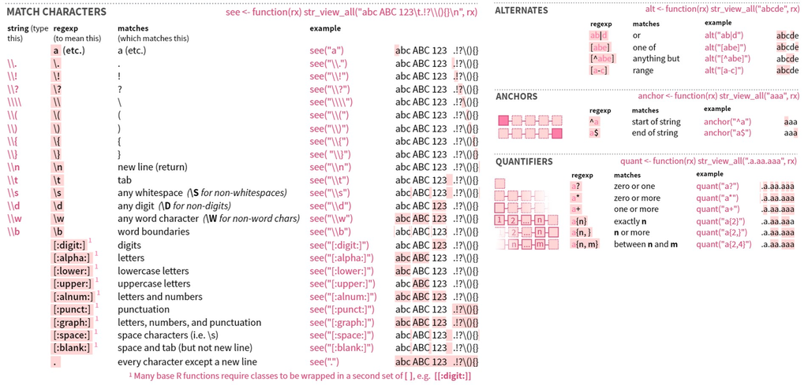

# PURRR

[figure not shown]

> [CHEATSHEET](https://github.com/rstudio/cheatsheets/blob/master/purrr.pdf)

`purr` is a HUGE package enhancing R’s functional programming (FP) toolkit by providing a complete and consistent set of tools for working with functions and vectors. It is very useful when working with **lists**.

There’s a lot of functionality regarding list management. As the entire content is overwhelming, only most remarkable functionalities will be mentioned.

> **SOME TRAINING**  
> Prepare a **named list** containing previous datasets:  
> - `fpkm_sep`: Pass `Gene_ID` to row names; remove `Short_name` and `Locus` columns; transpose the data frame; Pass row names to a new first column called “Sample”.  
> - `microb`: Add ‘OTU_’ string to start of row names; remove all taxonomy columns; transpose the data frame; Pass row names to a new first column called “Sample”.  
> - `phenot_sub`: Pass row names to a new first column called “Sample”.  
> Store the modified datasets in new variables (`fpkm_lst`, `microb_lst`).

```r
# FPKM dataset list
fpkm_lst <- select(fpkm_sep, -c(Short_name, Locus)) %>% column_to_rownames("Gene_ID") %>%
  t() %>% as.data.frame() %>% rownames_to_column("Sample")
# Microb dataset list
microb_lst <- microb
rownames(microb_lst) <- str_glue_data(microb_lst, "OTU_{row.names(microb)}")
microb_lst <- select_if(microb_lst, is.numeric) %>%
  t() %>% as.data.frame() %>% rownames_to_column("Sample")
# Phenot dataset list
phenot_lst <- rownames_to_column(phenot_sub, "Sample")
# Full list
datalist <- list("RNASEQ" = fpkm_lst, "16S"= microb_lst, "METAD" = phenot_lst)
```

## Apply functions: A bunch of functions working as `lapply()`.

[output not shown]

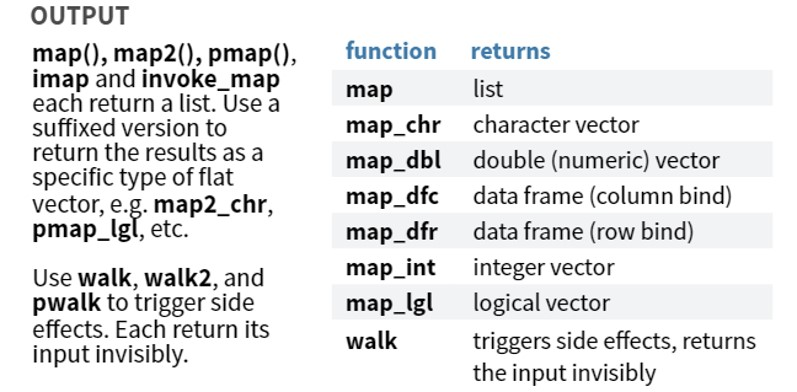

```r
map(datalist, as_tibble)
```

## Reduce lists: Apply recursively a function over all list elements.

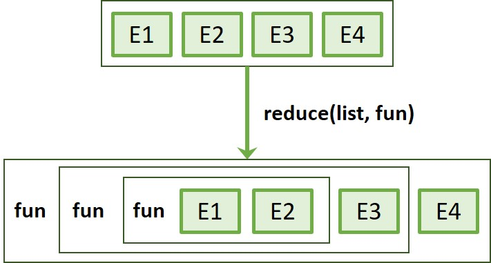

This is specially interesting when trying to **merge** (or **join**) multiple data frames.

```r
compldata <- reduce(datalist, left_join, by = "Sample")
compldata[1:6,c(1:3,67:69,74:79)]
```

```
##   Sample XLOC_000013 XLOC_000014 OTU_1 OTU_2 OTU_3 Breed Diet Weight_kg LoinW_1 LoinW_2 WHC_dec
## 1   Sam1     7.24214    53.33680  5242   101  2010    IB    1     120.1    2.19    2.40 0.21504
## 2   Sam2     7.08509   104.98300  1597     0   500    DU    1     135.4    2.28    2.24 0.23734
## 3   Sam3     7.49345    75.67790     0     0   375    IB    1     133.2    2.29    2.36 0.20632
## 4   Sam4     6.03476    55.77290  2312  2644  2602    IB    1     129.4    2.26    2.40 0.24609
## 5   Sam5     9.13230    83.50975     0     0  4702    DU    1     136.6    1.95    1.89 0.24204
## 6   Sam6     7.98947    64.50950  1994  2415  1343    DU    1     133.3    2.53    2.46 0.25259
```

Lets save our modified dataset:

```r
write.table(compldata, file = "data/compldata.tsv", quote = FALSE, sep = "\t", dec = ".", row.names = FALSE)
```

# FORCATS

[figure not shown]

> [OVERVIEW](https://forcats.tidyverse.org/)

R uses factors to handle categorical variables, variables that have a fixed and known set of possible values. Factors are also helpful for reordering character vectors to improve display. The goal of the `forcats` package is to provide a suite of tools that solve common problems with factors, including changing the order of levels or the values.

- `fct_reorder()`: Reordering a factor by another variable.
- `fct_infreq()`: Reordering a factor by the frequency of values.
- `fct_relevel()`: Changing the order of a factor by hand.
- `fct_lump()`: Collapsing the least/most frequent values of a factor into “other”.